# Lecture 12 - Factorial ANOVA of Penguin Mass Balanced

Author

Bill Perry

# Lecture 11: Review

### ANOVA

- Analysis of variance: single and multi-factor designs
- Examples: diatoms, circadian rhythms
- Predictor variables: fixed vs. random
- ANOVA model
- Analysis and partitioning of variance
- Null hypothesis
- Assumptions and diagnostics
- Post F Tests - Tukey and others
- Reporting the results

[figure not shown]

# Lecture 12: Factorial ANOVA

### 2-factor designs (2-way ANOVA)

- very common in ecology
- can have more factors (e.g., 3-way ANOVA) but interpretation gets very challenging…
- Most multifactor designs: are factorial or nested
- We will cover a 2 Factor Anova - this could be fertilizer and sunlight for plant biomass produced…
  - each can have an effect independently
  - the effect of one factor may interact with the other factor
  - in this example…
    - a low light and high light treatment might affect biomass
    - fertilizer also might affect plant biomass
    - but when you have higher light the high fertilizer treatment may grow better than expected

[figure not shown]

[figure not shown]

# Factorial ANOVA: Design Structure

### Consider two factors:

- Factorial/crossed:
  - every level of B in every level of A

[figure not shown]

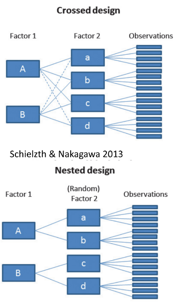

# Factorial ANOVA: Effect Types

### In factorial designs

- look at two types of factor effects:
  - **Main effect of each factor** (polling across other factor)
  - **Interaction effects;** is there synergistic/ antagonistic effect of factors?

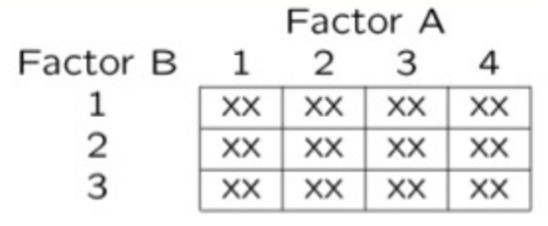

# Introduction to Two-Way ANOVA

## Factorial Designs

Two-way ANOVA examines:

- Main effect of Factor A (Species)
- Main effect of Factor B (Sex)
- Interaction between A × B
- Balanced design: equal sample sizes in all cells
- Type III sums of squares for unbiased estimates - if balanced it does not matter

```
## # A tibble: 6 × 6
##   species   sex        n mean_mass sd_mass se_mass
##   <fct>     <fct>  <int>     <dbl>   <dbl>   <dbl>
## 1 Adelie    female    73     3369.    269.    31.5
## 2 Adelie    male      73     4043.    347.    40.6
## 3 Chinstrap female    34     3527.    285.    48.9
## 4 Chinstrap male      34     3939.    362.    62.1
## 5 Gentoo    female    58     4680.    282.    37.0
## 6 Gentoo    male      61     5485.    313.    40.1
```

# Data Preparation - Creating Balanced Design

### Balancing the Penguin Data

The dataframe of penguins is unbalanced - there are unequal samples per cell

```
## # A tibble: 3 × 3
##   species   female  male
##   <fct>      <int> <int>
## 1 Adelie        73    73
## 2 Chinstrap     34    34
## 3 Gentoo        58    61
```

```
## Minimum n = 34
## # A tibble: 3 × 3
##   species   female  male
##   <fct>      <int> <int>
## 1 Adelie        34    34
## 2 Chinstrap     34    34
## 3 Gentoo        34    34
```

Statistical Mode $Y_{ijk} = \mu + \alpha_i + \beta_j + (\alpha\beta)_{ij} + \varepsilon_{ijk}$

Where:

$\mu$ = grand mean

$\alpha_i$ = effect of species i

$\beta_j$ = effect of sex j

$(\alpha\beta)_{ij}$ = interaction effect

$\varepsilon_{ijk}$ = random error

# Descriptive Statistics

## Summary Statistics by Groups

```
## # A tibble: 6 × 6
##   species   sex        n mean_mass sd_mass se_mass
##   <fct>     <fct>  <int>     <dbl>   <dbl>   <dbl>
## 1 Adelie    female    34     3335.    260.    44.5
## 2 Adelie    male      34     4049.    318.    54.5
## 3 Chinstrap female    34     3527.    285.    48.9
## 4 Chinstrap male      34     3939.    362.    62.1
## 5 Gentoo    female    34     4681.    309.    53.0
## 6 Gentoo    male      34     5525     274.    47.0
```

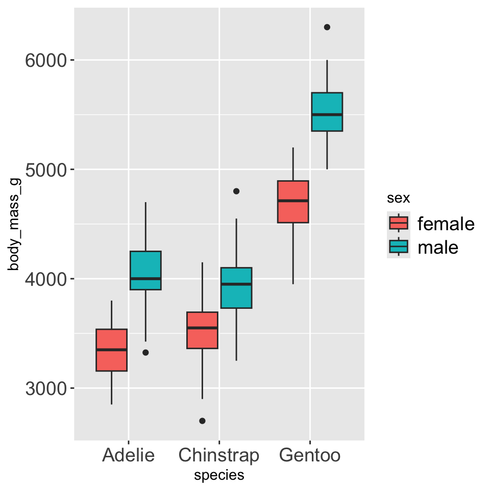

# Factorial ANOVA Models

Factorial designs can be of 3 types:

- **Model 1** - 2 fixed factors - the focus for today….
- Model 2 - 2 random
- **Model 3** - 1 fixed, 1 random (mixed model) - often nested

Model 1 ANOVA:

### $$y_{ijk} = \mu + \alpha_i + \beta_j + (\alpha\beta)_{ij} + \varepsilon_{ijk}$$

# Model Components Explained

### $$y_{ijk} = \mu + \alpha_i + \beta_j + (\alpha\beta)_{ij} + \varepsilon_{ijk}$$

- $y_{ijk}$: value of the k<sub>th</sub> observation from jth and ith combination of B and A (sex m of species y)
- µ: overall mean (overall mass)
- αi: effect of the ith level of A, pooling across all levels of B: µi- µ (difference between average mass in all “males” for species x and overall mean)

# Interaction Effects

### $$y_{ijk} = \mu + \alpha_i + \beta_j + (\alpha\beta)_{ij} + \varepsilon_{ijk}$$

- Βj: effect of jth level of B, pooling across all levels of A: µj- µ (difference between average mass in all males treatments and overall mean)
- (αβ)ij: effect of interaction of ith level of A and jth level of B (µij - µi - µj + µ).
  - Does effect of B depend on level of A? (is effect of sex different in the 3 species?)

# Model Types and Interpretation

### $$y_{ijk} = \mu + \alpha_i + \beta_j + (\alpha\beta)_{ij} + \varepsilon_{ijk}$$

- Model 2 ANOVA rare in ecology
- **Model 3 interpretation is different:**
  - βj: random variable measuring variance in y across all possible levels of B, pooling across all levels of A
  - (αβ)ij is random variable measuring variance of interaction between A and B across all possible levels of B (“is effect of A consistent across all possible levels of B that could have been chosen?”)

# Estimated Marginal Means

- Before we go further we need to define what estimated marginal means are
- Balanced data - it is just the means of the groups… easy
- Unbalanced data - it is the mean of cells that represent the lowest average of the groups

```
## Combined table with means and counts:
## # A tibble: 3 × 5
##   species   female_mean male_mean female_n male_n
##   <fct>           <dbl>     <dbl>    <int>  <int>
## 1 Adelie          3369.     4043.       73     73
## 2 Chinstrap       3527.     3939.       34     34
## 3 Gentoo          4680.     5485.       58     61
##
##
## Regular means (WRONG for marginal means):
## # A tibble: 3 × 3
##   species   total_n regular_mean
##   <fct>       <int>        <dbl>
## 1 Adelie        146        3706.
## 2 Chinstrap      68        3733.
## 3 Gentoo        119        5092.
```

```
## Estimated Marginal Means for Species (CORRECT):
## # A tibble: 3 × 3
##   species   emm_mean calculation
##   <fct>        <dbl> <chr>
## 1 Adelie       3706. (3368.8 + 4043.5) / 2 = 3706.2
## 2 Chinstrap    3733. (3527.2 + 3939) / 2 = 3733.1
## 3 Gentoo       5082. (4679.7 + 5484.8) / 2 = 5082.3
##
##
## Comparison showing EMM calculation:
## # A tibble: 3 × 6
##   species   cell_mean_female cell_mean_male species_emm regular_mean difference
##   <fct>                <dbl>          <dbl>       <dbl>        <dbl>      <dbl>
## 1 Adelie               3369.          4043.       3706.        3706.   4.55e-13
## 2 Chinstrap            3527.          3939.       3733.        3733.   0
## 3 Gentoo               4680.          5485.       5082.        5092.  -1.01e+ 1
```

# Estimated Marginal Means

- Before we go further we need to define what estimated marginal means are
- Balanced data - it is just the means of the groups… easy
- Unbalanced data - it is the mean of cells that represent the lowest average of the groups

```
## Combined table with means and counts:
## # A tibble: 3 × 5
##   species   female_mean male_mean female_n male_n
##   <fct>           <dbl>     <dbl>    <int>  <int>
## 1 Adelie          3369.     4043.       73     73
## 2 Chinstrap       3527.     3939.       34     34
## 3 Gentoo          4680.     5485.       58     61
```

```
##
## Regular means sex (WRONG for marginal means):
## # A tibble: 2 × 3
##   sex    total_n regular_mean
##   <fct>    <int>        <dbl>
## 1 female     165        3862.
## 2 male       168        4546.
##
##
## Estimated Marginal Means for Sex (CORRECT):
## # A tibble: 2 × 3
##   sex    emm_mean calculation
##   <fct>     <dbl> <chr>
## 1 female    3859. (3368.8 + 3527.2 + 4679.7) / 3 = 3858.6
## 2 male      4489. (4043.5 + 3939 + 5484.8) / 3 = 4489.1
## \n
## Comparison showing difference between regular and marginal means:
## # A tibble: 2 × 5
##   sex    total_n regular_mean emm_mean difference
##   <fct>    <int>        <dbl>    <dbl>      <dbl>
## 1 female     165        3862.    3859.      -3.68
## 2 male       168        4546.    4489.     -56.6
```

# ANOVA Table Structure

- SStotal = SSA + SSB + SSAB + SSresidual
- SStotal = (Y - Grand Mean Y)^2
- SSresidual = (Y -Yhat)^2 or the difference between each observation and the appropriate cell mean, summed over all observations

| Source | SS | df | MS |
| --- | --- | --- | --- |
| A | $nq \sum_{i=1 }^{p} (\bar {y}_{i.} - \bar{y})^2$ | $p-1$ | $\frac{SS_A} {p-1}$ |
| B | $np \sum_{j=1 }^{q} (\bar {y}_{.j} - \bar{y})^2$ | $q-1$ | $\frac{SS_B} {q-1}$ |
| AB | $n \sum_{i=1 }^{p} \sum_{ j=1}^{q} (\ bar{y}_{ij} - \bar{y}_ {i.} - \bar {y}_{.j} + \bar{y})^2$ | $(p-1)(q-1)$ | $\frac{SS_{AB }}{(p-1)(q-1) }$ |
| Residual | $\sum_{i=1} ^{p} \sum_{ j=1}^{q} \sum_{k=1}^{ n} (y_{ijk} - \bar{y}_{ ij})^2$ | $pq(n-1)$ | $\frac{SS_{\ text{Residual }}}{pq(n-1)}$ |
| Total | $\sum_{i=1} ^{p} \sum_{ j=1}^{q} \sum_{k=1}^{ n} (y_{ijk} - \bar{y})^2$ | $pqn-1$ |  |

# SSA: Factor A Effects

- SSA is SS of differences between each marginal mean of A and overall mean
- If A is species then get the emmeans for factor A down and subtract from overall mean

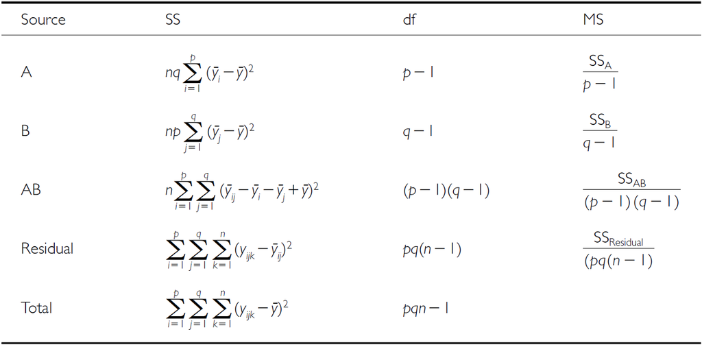

# SSB: Factor B Effects

- SSB is SS of differences between each marginal mean of B and overall mean
- If B is sex then get the emmeans for factor B across and subtract from overall mean

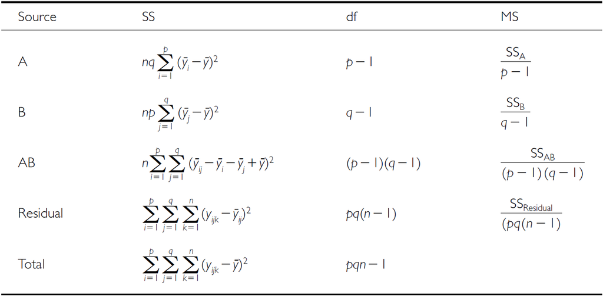

# SSAB: Interaction Effects

- SSAB is SS of cell means minus marginal means plus overall mean

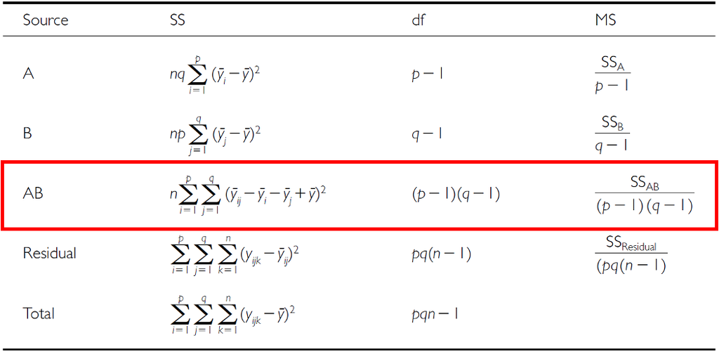

# F-ratio Calculations

- SS converted to MS;
- F-ratio calculations are different depending on whether factors are fixed, random or mixed

| Source | A and B fixed | A and B random | A fixed, B random |
| --- | --- | --- | --- |
| A | $\frac{MS_A}{MS_{ Residual}}$ | $\frac{MS_A}{MS_{AB}}$ | $\frac{MS_A}{MS_{AB}}$ |
| B | $\frac{MS_B}{MS_{ Residual}}$ | $\frac{MS_B}{MS_{AB}}$ | $\frac{MS_B}{MS_{AB}}$ |
| AB | $\frac{MS_{AB}}{MS_{ Residual}}$ | $\frac{MS_{AB}}{MS_{ Residual}}$ | $\frac{MS_{AB}}{MS_{ Residual}}$ |

# Hypotheses: Fixed Factors

- 3 hypotheses are tested in a two-way factorial ANOVA:
- A, B, A*B Both factors fixed:
  - Ho(A): µ1= µ2= µ3=…. µi= µp (no diff. in marginal means of A, pooling across all levels of B)
  - Ho(B): µ1= µ2= µ3=…. µj= µq (no diff. in marginal means of B, pooling across all levels of A)
  - Ho(AB): µij- µi - µj + µ = 0 (no effect of interaction)

# Hypotheses: Mixed Model

- 3 hypotheses are tested in a two-way factorial ANOVA: A, B, A*B
- One fixed, one random:
  - Ho(A): µ1= µ2= µ3=…. µi= µp (no diff. in marginal means of A, pooling across all levels of B)
  - Ho(B): σB2= 0 (no added variance due to levels of B that could have been used)
  - Ho(AB): σAB2= 0 (no added variance due to interaction between all levels of A and B that could have been used)

# Example Study Details

So lets try the example with the penguin data that is in the package penguin

- Effect of species and sex on body_mass_g
  - 3 species (factor A)
  - 2 sexes (factor B)
  - 34 replicates in each cell
  - This analysis examines the effects of species and sex on the body mass of penguins.

[figure not shown]

# Two-Way ANOVA with Type III Sums of Squares

## Fitting the Model

```
##
## Call:
## lm(formula = body_mass_g ~ species * sex, data = balanced_df)
##
## Residuals:
##     Min      1Q  Median      3Q     Max
## -827.21 -178.13    6.25  175.00  861.03
##
## Coefficients:
##               Estimate Std. Error t value Pr(>|t|)
## (Intercept)    4175.86      21.23 196.727  < 2e-16 ***
## species1       -484.31      30.02 -16.134  < 2e-16 ***
## species2       -442.77      30.02 -14.750  < 2e-16 ***
## sex1           -328.31      21.23 -15.467  < 2e-16 ***
## species1:sex1   -28.68      30.02  -0.955    0.341
## species2:sex1   122.43      30.02   4.078 6.57e-05 ***
## ---
## Signif. codes:  0 '***' 0.001 '**' 0.01 '*' 0.05 '.' 0.1 ' ' 1
##
## Residual standard error: 303.2 on 198 degrees of freedom
## Multiple R-squared:  0.8596, Adjusted R-squared:  0.856
## F-statistic: 242.4 on 5 and 198 DF,  p-value: < 2.2e-16
```

```
## Type III Sums of Squares ANOVA:
## Anova Table (Type III tests)
##
## Response: body_mass_g
##                 Sum Sq  Df    F value    Pr(>F)
## (Intercept) 3557308900   1 38701.5271 < 2.2e-16 ***
## species       87725999   2   477.2049 < 2.2e-16 ***
## sex           21988483   1   239.2224 < 2.2e-16 ***
## species:sex    1672776   2     9.0994 0.0001657 ***
## Residuals     18199467 198
## ---
## Signif. codes:  0 '***' 0.001 '**' 0.01 '*' 0.05 '.' 0.1 ' ' 1
```

# Understanding Type III SS

Type III sums of squares test each effect after adjusting for all other effects in the model:

- **Species effect**: Tested after adjusting for sex and interaction
- **Sex effect**: Tested after adjusting for species and interaction
- **Interaction**: Tested after adjusting for both main effects

This is especially important for unbalanced designs, but we’re using it here for consistency with the next analysis.

```
## Effect Sizes (Eta-squared):
##        Effect Eta_Squared
## 1     Species  0.67696748
## 2         Sex  0.16968160
## 3 Interaction  0.01290854
```

# Checking Model Assumptions

Assumption Plots

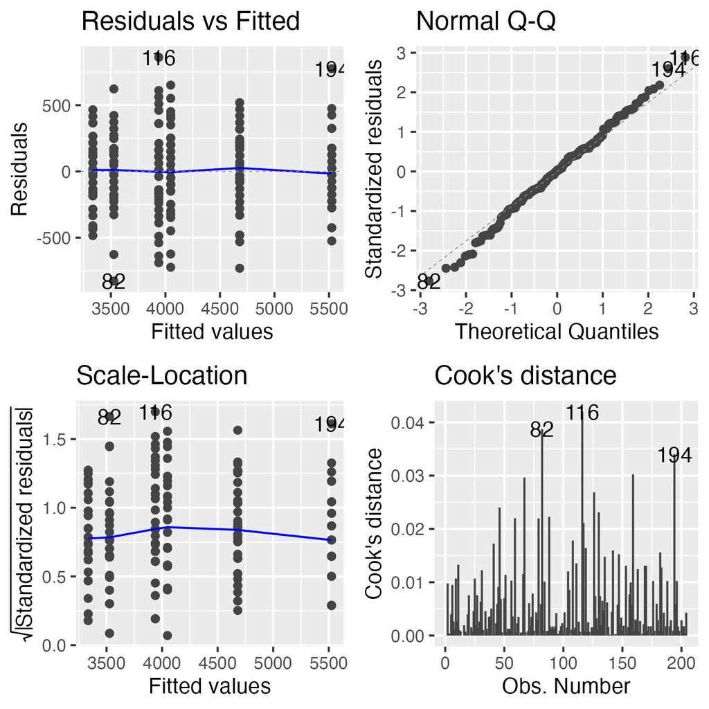

# Formal Tests

- These are the formal tests of
  - normality of residuals
  - homogeneity of variances

```
## Shapiro-Wilk Normality Test:
##
##  Shapiro-Wilk normality test
##
## data:  residuals(anova_model)
## W = 0.99612, p-value = 0.8886
## Levene's Test for Homogeneity:
## Levene's Test for Homogeneity of Variance (center = median)
##        Df F value Pr(>F)
## group   5  0.7841 0.5622
##       198
## Number of outliers (|z| > 3): 0
```

# Estimated Marginal Means (EMMs)

## Computing EMMs

```
## Species EMMs:
##  species   emmean   SE  df lower.CL upper.CL
##  Adelie      3692 36.8 198     3619     3764
##  Chinstrap   3733 36.8 198     3661     3806
##  Gentoo      5103 36.8 198     5030     5175
##
## Results are averaged over the levels of: sex
## Confidence level used: 0.95
## Sex EMMs:
##  sex    emmean SE  df lower.CL upper.CL
##  female   3848 30 198     3788     3907
##  male     4504 30 198     4445     4563
##
## Results are averaged over the levels of: species
## Confidence level used: 0.95
## Species by Sex EMMs:
##  species   sex    emmean SE  df lower.CL upper.CL
##  Adelie    female   3335 52 198     3232     3437
##  Chinstrap female   3527 52 198     3425     3630
##  Gentoo    female   4681 52 198     4578     4783
##  Adelie    male     4049 52 198     3946     4151
##  Chinstrap male     3939 52 198     3836     4042
##  Gentoo    male     5525 52 198     5422     5628
##
## Confidence level used: 0.95
```

## Pairwise Comparisons

```
## [1] "Species pairwise comparisons:\n"
##  contrast           estimate SE  df t.ratio p.value
##  Adelie - Chinstrap    -41.5 52 198  -0.799  0.7041
##  Adelie - Gentoo     -1411.4 52 198 -27.145  <.0001
##  Chinstrap - Gentoo  -1369.9 52 198 -26.346  <.0001
##
## Results are averaged over the levels of: sex
## P value adjustment: tukey method for comparing a family of 3 estimates
## [1] "Species comparisons within sex:"
## sex = female:
##  contrast           estimate   SE  df t.ratio p.value
##  Adelie - Chinstrap     -193 73.5 198  -2.620  0.0256
##  Adelie - Gentoo       -1346 73.5 198 -18.310  <.0001
##  Chinstrap - Gentoo    -1154 73.5 198 -15.690  <.0001
##
## sex = male:
##  contrast           estimate   SE  df t.ratio p.value
##  Adelie - Chinstrap      110 73.5 198   1.490  0.2979
##  Adelie - Gentoo       -1476 73.5 198 -20.079  <.0001
##  Chinstrap - Gentoo    -1586 73.5 198 -21.569  <.0001
##
## P value adjustment: tukey method for comparing a family of 3 estimates
```

# Post F Test of the interaction

What we need to do if the interaction is significant is to test the overall interaction and ignore the main effects!!!

# Interaction tests continued

```
##  species   sex      emmean       SE  df lower.CL upper.CL .group
##  Adelie    female 3334.559 51.99448 198 3196.378 3472.740  a
##  Adelie    male   4048.529 51.99448 198 3910.349 4186.710   b
##  Chinstrap female 3527.206 51.99448 198 3389.025 3665.387  a
##  Chinstrap male   3938.971 51.99448 198 3800.790 4077.151   b
##  Gentoo    female 4680.882 51.99448 198 4542.702 4819.063    c
##  Gentoo    male   5525.000 51.99448 198 5386.819 5663.181     d
##
## Confidence level used: 0.95
## Conf-level adjustment: sidak method for 6 estimates
## P value adjustment: sidak method for 15 tests
## significance level used: alpha = 0.05
## NOTE: If two or more means share the same grouping symbol,
##       then we cannot show them to be different.
##       But we also did not show them to be the same.
```

# interaction plot

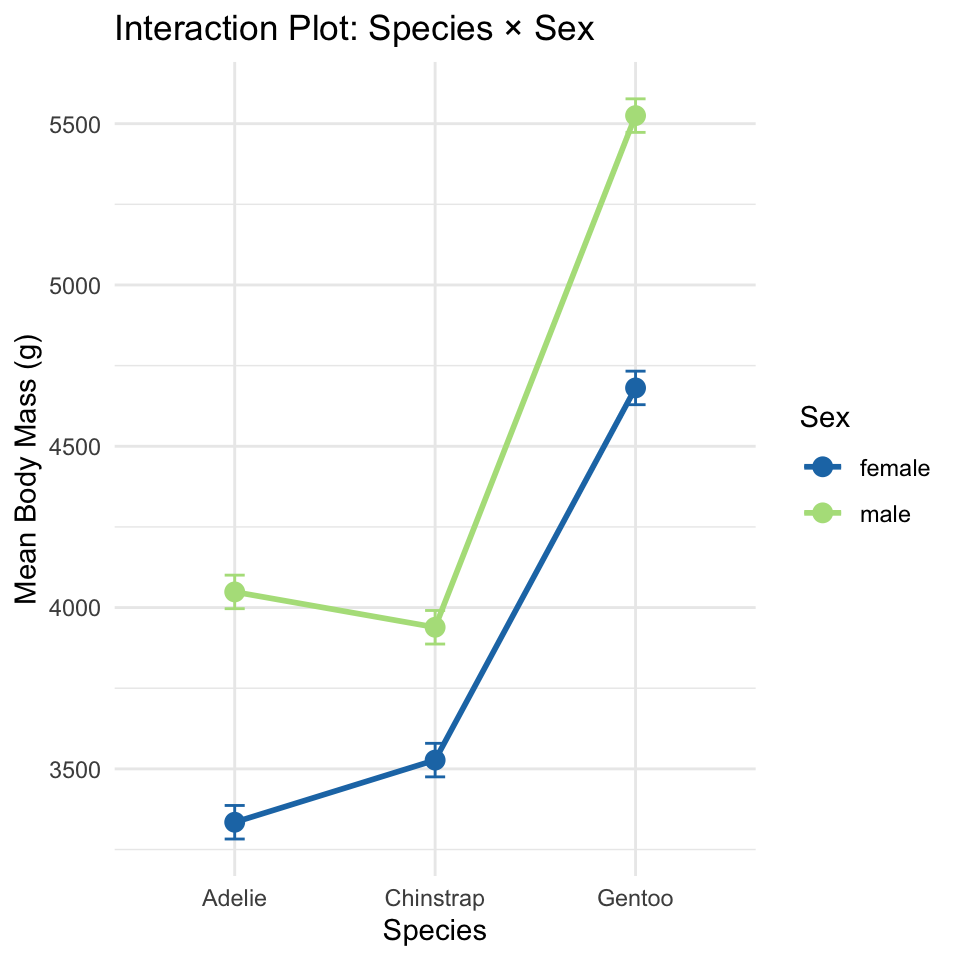

# Introduction to Unbalanced Designs

The Challenge of Unbalanced Data

- Real-world data is often unbalanced:
  - Unequal sample sizes across groups
  - Missing data patterns
  - Natural variation in sampling
- Key Issues:
  - Type I, II, and III SS give different results
  - Order of terms matters for Type I SS
  - Marginal means ≠ Simple averages Interpretation becomes complex

Statistical Model (same as balanced):
$$Y_{ijk} = \mu + \alpha_i + \beta_j + (\alpha\beta)_{ij} + \varepsilon_{ijk}$$

But parameter estimation differs!

### Data Preparation - Using Natural Unbalanced Data

```
## [1] "Unbalanced sample sizes:"
## # A tibble: 6 × 3
##   species   sex        n
##   <fct>     <fct>  <int>
## 1 Adelie    female    73
## 2 Adelie    male      73
## 3 Chinstrap female    34
## 4 Chinstrap male      34
## 5 Gentoo    female    58
## 6 Gentoo    male      61
## [1] "Total N = 333"
## [1] "Imbalance ratio = 2.15"
```

## Visualizing Imbalance

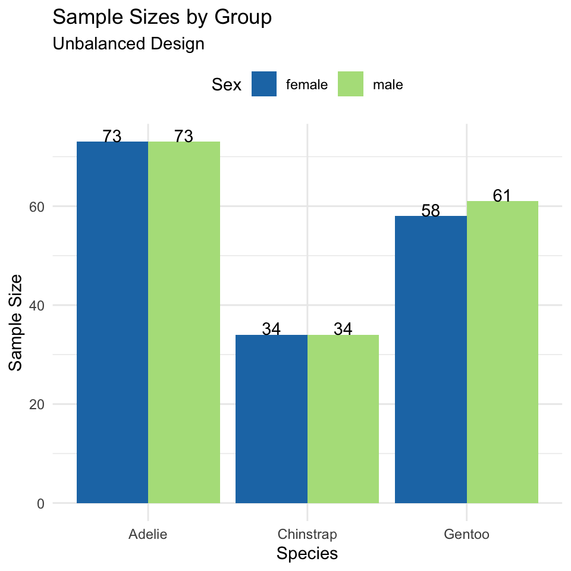

# Understanding Sums of Squares Types

## Type I (Sequential) SS

```
## Type I SS (Species → Sex → Interaction):
## Analysis of Variance Table
##
## Response: body_mass_g
##              Df    Sum Sq  Mean Sq F value    Pr(>F)
## species       2 145190219 72595110 758.358 < 2.2e-16 ***
## sex           1  37090262 37090262 387.460 < 2.2e-16 ***
## species:sex   2   1676557   838278   8.757 0.0001973 ***
## Residuals   327  31302628    95727
## ---
## Signif. codes:  0 '***' 0.001 '**' 0.01 '*' 0.05 '.' 0.1 ' ' 1
##
##
## Type I SS (Sex → Species → Interaction):
## Analysis of Variance Table
##
## Response: body_mass_g
##              Df    Sum Sq  Mean Sq F value    Pr(>F)
## sex           1  38878897 38878897 406.145 < 2.2e-16 ***
## species       2 143401584 71700792 749.016 < 2.2e-16 ***
## sex:species   2   1676557   838278   8.757 0.0001973 ***
## Residuals   327  31302628    95727
## ---
## Signif. codes:  0 '***' 0.001 '**' 0.01 '*' 0.05 '.' 0.1 ' ' 1
##
##
## Type I SS depends on order:
##    Effect Order1_SS Order2_SS
## 1 Species 145190219 143401584
## 2     Sex  37090262  38878897
```

## How Type I SS Works

**Sequential decomposition:**

1. **First term** gets all SS it can explain
2. **Second term** gets SS after removing first
3. **Third term** gets SS after removing first two
- **Example calculation:**
  - SS(Species) = reduction in SS from null to species-only model
  - SS(Sex|Species) = additional reduction adding sex
  - SS(Interaction|Species,Sex) = additional reduction adding interaction
- **Problems with unbalanced data:**
  - Order dependency
  - Biased if factors are correlated
  - Not invariant to coding

# Type III Sums of Squares

## Type III (Marginal) SS

```
## [1] "Type III Sums of Squares:"
## Anova Table (Type III tests)
##
## Response: body_mass_g
##                 Sum Sq  Df   F value    Pr(>F)
## (Intercept) 5232595969   1 54661.828 < 2.2e-16 ***
## species      143001222   2   746.924 < 2.2e-16 ***
## sex           29851220   1   311.838 < 2.2e-16 ***
## species:sex    1676557   2     8.757 0.0001973 ***
## Residuals     31302628 327
## ---
## Signif. codes:  0 '***' 0.001 '**' 0.01 '*' 0.05 '.' 0.1 ' ' 1
## [1] "Comparison of F-values:"
##        Effect Type_I_F Type_III_F
## 1     Species   758.36     746.92
## 2         Sex   387.46     311.84
## 3 Interaction     8.76       8.76
```

## How Type III SS Works

- **Marginal decomposition:**
  - Each effect tested after adjusting for all others:
    - SS(Species|Sex,Interaction)
    - SS(Sex|Species,Interaction)
    - SS(Interaction|Species,Sex)
- **Advantages:**
  - Order invariant
  - Tests hypotheses about unweighted means
  - Standard in most software
- **Disadvantages:**
  - Lower power with missing cells
  - Tests may not be orthogonal
  - Requires careful interpretation

```
## [1] "Effect Sizes (Type III):"
##        Effect Eta_Squared
## 1     Species      0.6947
## 2         Sex      0.1450
## 3 Interaction      0.0081
```

# Manual SS Calculation Demonstration

## Computing SS Step-by-Step

```
## [1] "Grand mean: 4207.1"
## [1] "Total SS: 215259666"
## [1] "Between-groups SS: 183957038"
## [1] "Within-groups SS: 31302628"
## [1] "Check: Between + Within = 215259666"
```

## Decomposing Between-Group SS

```
## SS(Species alone): 145190219
## SS(Sex alone): 38878897
##
##
## Sum of main effects: 184069116
## Actual between SS: 183957038
##
##
## Difference (due to correlation): -112078
```

# Estimated Marginal Means - Unbalanced Data

### Computing EMMs

[output not shown]

# Interaction tests continued

```
##  species   sex      emmean       SE  df lower.CL upper.CL .group
##  Adelie    female 3368.836 36.21222 327 3272.980 3464.692  a
##  Adelie    male   4043.493 36.21222 327 3947.637 4139.349   b
##  Chinstrap female 3527.206 53.06120 327 3386.749 3667.662  a
##  Chinstrap male   3938.971 53.06120 327 3798.514 4079.427   b
##  Gentoo    female 4679.741 40.62586 327 4572.202 4787.281    c
##  Gentoo    male   5484.836 39.61427 327 5379.975 5589.698     d
##
## Confidence level used: 0.95
## Conf-level adjustment: sidak method for 6 estimates
## P value adjustment: sidak method for 15 tests
## significance level used: alpha = 0.05
## NOTE: If two or more means share the same grouping symbol,
##       then we cannot show them to be different.
##       But we also did not show them to be the same.
```

# Pairwise Comparisons

### Tukey HSD Comparisons

```
## Species pairwise comparisons (Tukey):
##  contrast           estimate   SE  df t.ratio p.value
##  Adelie - Chinstrap    -26.9 45.4 327  -0.593  0.8241
##  Adelie - Gentoo     -1376.1 38.2 327 -36.007  <.0001
##  Chinstrap - Gentoo  -1349.2 47.0 327 -28.682  <.0001
##
## Results are averaged over the levels of: sex
## P value adjustment: tukey method for comparing a family of 3 estimates
##
##
## Sex effect within each species:
## species = Adelie:
##  contrast      estimate   SE  df t.ratio p.value
##  female - male     -675 51.2 327 -13.174  <.0001
##
## species = Chinstrap:
##  contrast      estimate   SE  df t.ratio p.value
##  female - male     -412 75.0 327  -5.487  <.0001
##
## species = Gentoo:
##  contrast      estimate   SE  df t.ratio p.value
##  female - male     -805 56.7 327 -14.188  <.0001
```

### Interaction Contrasts

[output not shown]

# Diagnostic Plots - Unbalanced Design

## Model Diagnostics

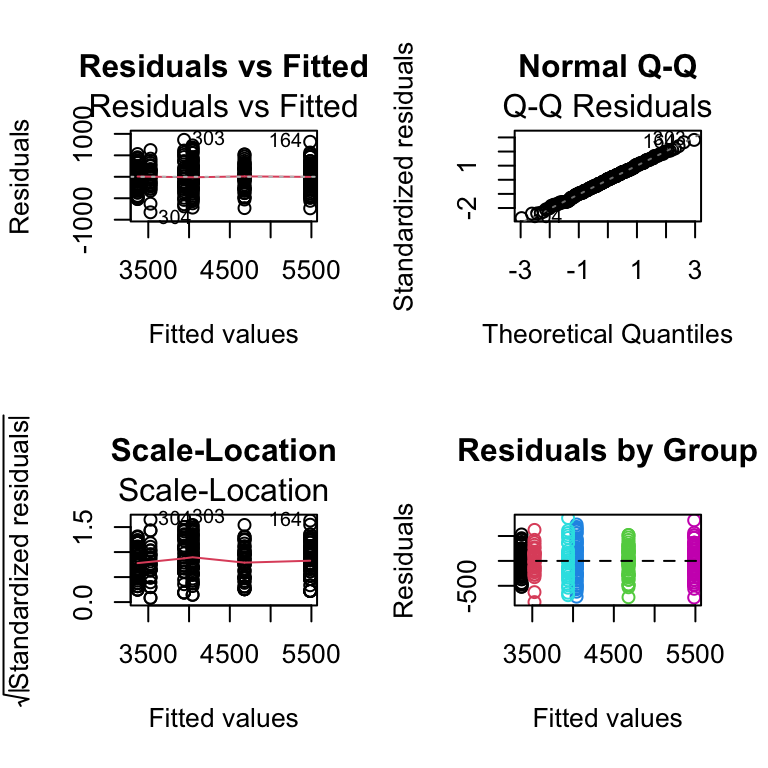

## Assumption Tests

```
## [1] "Shapiro-Wilk test:"
##
##  Shapiro-Wilk normality test
##
## data:  residuals(model_u)
## W = 0.99776, p-value = 0.9367
## [1] "\nLevene's test:"
## Levene's Test for Homogeneity of Variance (center = median)
##        Df F value Pr(>F)
## group   5  1.3908 0.2272
##       327
## [1] "\nResidual SD by group:"
## # A tibble: 6 × 3
##   species   sex    sd_resid
##   <fct>     <fct>     <dbl>
## 1 Adelie    female     269.
## 2 Adelie    male       347.
## 3 Chinstrap female     285.
## 4 Chinstrap male       362.
## 5 Gentoo    female     282.
## 6 Gentoo    male       313.
```

# Comparing Balanced vs Unbalanced Results

## Side-by-Side Comparison

```
## Balanced vs Unbalanced Results:
##        Effect Balanced_F Balanced_p Unbalanced_F Unbalanced_p
## 1     Species     477.20      0e+00       746.92        0e+00
## 2         Sex     239.22      0e+00       311.84        0e+00
## 3 Interaction       9.10      2e-04         8.76        2e-04
##
##
## Sample sizes:
## Balanced total N: 204
## Unbalanced total N: 333
## Data discarded: 129 observations
```

## Visual Comparison

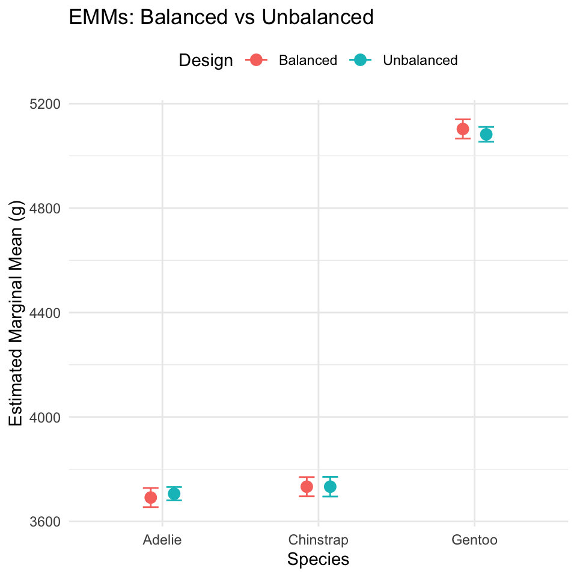

# Summary and Best Practices

### Unbalanced Designs:

**Challenges:** - Type I SS depends on order - Simple means ≠ EMMs - Reduced power for interactions - Complex interpretation

**Solutions:** - Use Type III SS for main effects - Report EMMs, not simple means - Check assumptions carefully - Consider impact of imbalance

### Recommendations:

1. **Always report:**
   - Sample sizes per cell
   - Type of SS used
   - EMMs with CIs
2. **Visualization:**
   - Show actual data points
   - Include error bars
   - Note unequal sample sizes
3. **Interpretation:**
   - Focus on effect sizes
   - Consider practical significance
   - Acknowledge limitations

# Final Recommendations

**For Experimental Studies:** - Design for balance when possible - Randomize allocation - Plan for attrition

**For Observational Studies:** - Accept imbalance as reality - Use Type III SS - Report EMMs - Consider covariates (ANCOVA)

**Statistical Software Defaults:** - R: Type I (sequential) - SAS: Type III (marginal) - SPSS: Type III (marginal)

Always specify which type you’re using!

Back to top